# DataAnalysis

## 資料分析與視覺化繪圖

- Numpy
- Pandas
- Matplotlib

### 1. Numpy

**說明 : NumPy，全名為 Numerical Python 創建一種稱為 ndarray 的型別，彌補了原生 list 缺少的元素級別（element-wise）運算功能 主要用於資料處理上。Numpy 底層以 C 和 Fortran 語言實作，能快速操作多重維度的陣列**

1. 數據類型 : 整數, 浮點數 , 複數
2. 數組類型
3. 類型轉換
4. 創建數組；
5. 數組索引；
6. 數組切片；
7. 改變維度。

#### 1.0 安裝套件

- Python 2+ : pip install numpy
- Python 3+ : pip3 install numpy

```python
#### 1.1 引用套件
```

```python
import numpy as np
```

#### 1.2 初始化陣列

```python
# 使用Python 列表建立陣列
np.array([1,3,5])  #  [1 3 5]
np.array([[1,2,],[3,4],[5,6]])  # [[1 2] [3 4] [5 6]]

# 使用Numpy arange函數建立連續數值陣列
np.arange(1,10)  # [1 2 3 4 5 6 7 8 9]

# 使用Numpy linspace函數建立連續等距數值陣列
np.linspace(0,4,11) # [0.  0.4 0.8 1.2 1.6 2.  2.4 2.8 3.2 3.6 4. ]

# 建立填滿 0 的陣列
np.zeros([2, 3]) # [[0. 0. 0.] [0. 0. 0.]]

# 建立填滿 1 的陣列
np.ones([2, 3]) #[[1. 1. 1.] [1. 1. 1.]]

# 建立對角線為1的對角矩陣陣列
np.eye(10)

#[[1. 0. 0. 0. 0. 0. 0. 0. 0. 0.]
# [0. 1. 0. 0. 0. 0. 0. 0. 0. 0.]
# [0. 0. 1. 0. 0. 0. 0. 0. 0. 0.]
# [0. 0. 0. 1. 0. 0. 0. 0. 0. 0.]
# [0. 0. 0. 0. 1. 0. 0. 0. 0. 0.]
# [0. 0. 0. 0. 0. 1. 0. 0. 0. 0.]
# [0. 0. 0. 0. 0. 0. 1. 0. 0. 0.]
# [0. 0. 0. 0. 0. 0. 0. 1. 0. 0.]
# [0. 0. 0. 0. 0. 0. 0. 0. 1. 0.]
# [0. 0. 0. 0. 0. 0. 0. 0. 0. 1.]]

#建立隨機數值陣列
#rand : 给定維度生成[0,1]之間的數值陣列，包含0，不包含1
np.random.rand(5) # [0.15385879, 0.64608619, 0.72079961, 0.3115263 , 0.6021007 ]
np.random.rand(4,2)
np.random.rand(4,3,2)

#randn : 给定維度生成常態分佈的數值陣列 , N（0,1）
np.random.randn(5)
np.random.randn(4,2)
np.random.randn(4,3,2)

#randint : 给定維度生成隨機整數數值陣列
np.random.randint(6,size=5)
np.random.randint(2,10)
np.random.randint(-10,10,size=(2,2))

#從给定的一维陣列中生成随數值
demo_list = [10,20,30,40,50]
#demo_list = ['Acer', 'ASUS','DELL','HP', 'APPLE']
np.random.choice(demo_list,size=(2,5), p=[0.1,0.6,0.1,0.1,0.1])

#  從檔CSV案讀取資料
np.genfromtxt('data/NPdata.csv', delimiter=',')
```

```
array([[ 1., 10., 20., 30., 40., 50., 60.],
       [ 2., 12., 22., 32., 42., 52., 62.]])
```

#### 1.3 陣列訪問

```python
#一維照列
np1 = np.arange(0,10)
print(np1)
print("np1[0] = %d , np1[5] = %d" % (np1[0],np1[5]))
print("np1[:5] = ",np1[:5])
print("np1[3:7] = ",np1[3:7])
print("np1[6:] = ",np1[6:])
print(np1[1:6:2])
print(np1[1::2])
print(np1[::3])
```

```
[0 1 2 3 4 5 6 7 8 9]
np1[0] = 0 , np1[5] = 5
np1[:5] =  [0 1 2 3 4]
np1[3:7] =  [3 4 5 6]
np1[6:] =  [6 7 8 9]
[1 3 5]
[1 3 5 7 9]
[0 3 6 9]
```

```python
#使用布林遮罩來取值
np3 = np.array([1, 2, 3, 4, 5, 6])
print(np3 > 3)
```

```
[False False False  True  True  True]
```

```python
np3[np3<3]=0
print(np3)
```

```
[0 0 3 4 5 6]
```

#### 1.4 改變數組的維度

```python
#使用reshape 函數

#a = np.arange(18)
#print(a)
#print(a.reshape(2,3,3))

a = np.arange(18).reshape(2,3,3)
print(a)
```

```
[[[ 0  1  2]
  [ 3  4  5]
  [ 6  7  8]]

 [[ 9 10 11]
  [12 13 14]
  [15 16 17]]]
```

```python
#使用ravel函數 ,將數組轉為一維 , return view

print(a.ravel())

#使用 flatten 函數 ,將數組轉為一維, 使用記憶體來保存結果
print(a.flatten())
```

```
[ 0  1  2  3  4  5  6  7  8  9 10 11 12 13 14 15 16 17]
[ 0  1  2  3  4  5  6  7  8  9 10 11 12 13 14 15 16 17]
```

#### 1.5 組合數組

```python
a = np.arange(9).reshape(3,3)
a
```

```
array([[0, 1, 2],
       [3, 4, 5],
       [6, 7, 8]])
```

```python
# 純量計算
b = a * 3
b
```

```
array([[ 0,  3,  6],
       [ 9, 12, 15],
       [18, 21, 24]])
```

```python
# 水平組合
#使用 hstack()
np.hstack((a, b))

#使用 np.concatenate()
np.concatenate((a, b), axis=1)
```

```
array([[ 0,  1,  2,  0,  3,  6],
       [ 3,  4,  5,  9, 12, 15],
       [ 6,  7,  8, 18, 21, 24]])
```

```python
# 垂直組合
#使用 vstack()
np.vstack((a, b))
#使用 np.concatenate()
np.concatenate((a, b), axis=0)
```

```
array([[ 0,  1,  2],
       [ 3,  4,  5],
       [ 6,  7,  8],
       [ 0,  3,  6],
       [ 9, 12, 15],
       [18, 21, 24]])
```

```python
# 深度組合
# 使用 dstack()
c = np.dstack((a, b))
print(c)
print(c.shape)
```

```
[[[ 0  0]
  [ 1  3]
  [ 2  6]]

 [[ 3  9]
  [ 4 12]
  [ 5 15]]

 [[ 6 18]
  [ 7 21]
  [ 8 24]]]
(3, 3, 2)
```

```python
# 列組合
# 使用 column_stack()
# column_stack((a, b)) == hstack((a, b))
c = np.column_stack((a, b))
print(c)
print(c.shape)
```

```
[[ 0  1  2  0  3  6]
 [ 3  4  5  9 12 15]
 [ 6  7  8 18 21 24]]
(3, 6)
```

```python
# 行組合
# 使用 row_stack()
# row_stack((a,b)) == vstack((a, b))
np.row_stack((a, b))
```

```
array([[ 0,  1,  2],
       [ 3,  4,  5],
       [ 6,  7,  8],
       [ 0,  3,  6],
       [ 9, 12, 15],
       [18, 21, 24]])
```

#### 1.6 數組分割

```python
# 分割
a = np.arange(9).reshape(3,3)

print(a)

np.hsplit(a,3)

#np.split(a,3,axis = 1)
```

```
[[0 1 2]
 [3 4 5]
 [6 7 8]]
```

```
[array([[0],
        [3],
        [6]]), array([[1],
        [4],
        [7]]), array([[2],
        [5],
        [8]])]
```

```python
# 重直分割
a = np.arange(9).reshape(3,3)

print(a)

np.vsplit(a,3)

#np.split(a,3,axis = 0)
```

```
[[0 1 2]
 [3 4 5]
 [6 7 8]]
```

```
[array([[0, 1, 2]]), array([[3, 4, 5]]), array([[6, 7, 8]])]
```

```python
# 水平分割
a = np.arange(9).reshape(3,3)
print(a)

np.hsplit(a,3)

#np.split(a,3,axis = 1)
```

```
[[0 1 2]
 [3 4 5]
 [6 7 8]]
```

```
[array([[0],
        [3],
        [6]]), array([[1],
        [4],
        [7]]), array([[2],
        [5],
        [8]])]
```

```python
# 深度分割
a = np.arange(27).reshape(3,3,3)
print(a)

np.dsplit(a,3)
```

```
[[[ 0  1  2]
  [ 3  4  5]
  [ 6  7  8]]

 [[ 9 10 11]
  [12 13 14]
  [15 16 17]]

 [[18 19 20]
  [21 22 23]
  [24 25 26]]]
```

```
[array([[[ 0],
         [ 3],
         [ 6]],

        [[ 9],
         [12],
         [15]],

        [[18],
         [21],
         [24]]]), array([[[ 1],
         [ 4],
         [ 7]],

        [[10],
         [13],
         [16]],

        [[19],
         [22],
         [25]]]), array([[[ 2],
         [ 5],
         [ 8]],

        [[11],
         [14],
         [17]],

        [[20],
         [23],
         [26]]])]
```

#### 1.7 矩陣運算

##### 1.7.1 矩陣加減

- 矩陣加法有交換律,減法沒有交換律
- 矩陣加法有結合律,減法沒有結合律

```python
A = np.array([[12,23,14],[20,29,38],[3,6,10],[15,15,2]])
B = np.array([[13,33,22],[10,19,8],[30,0,20],[0,0,0]])
print(A+B)
print(B+A)
np.array_equal(A+B,B+A)
```

```
[[25 56 36]
 [30 48 46]
 [33  6 30]
 [15 15  2]]
[[25 56 36]
 [30 48 46]
 [33  6 30]
 [15 15  2]]
```

```
True
```

```python
A = np.array([[12,23,14],[20,29,38],[3,6,10],[15,15,2]])
B = np.array([[13,33,22],[10,19,8],[30,0,20],[0,0,0]])
print(A-B)
print(B-A)
np.array_equal(A-B,B-A)
```

```
[[ -1 -10  -8]
 [ 10  10  30]
 [-27   6 -10]
 [ 15  15   2]]
[[  1  10   8]
 [-10 -10 -30]
 [ 27  -6  10]
 [-15 -15  -2]]
```

```
False
```

```python
A = np.array([[5,3],[0,1]])
B = np.array([[4,-1],[2,3]])
C = np.array([[9,8],[-6,2]])
print((A+B)+C)
print(A+(B+C))

np.array_equal((A+B)+C,A+(B+C))
```

```
[[18 10]
 [-4  6]]
[[18 10]
 [-4  6]]
```

```
True
```

```python
np.array_equal((A-B)-C,A-(B-C))
```

```
False
```

##### 1.7.2 矩陣乘法

- 矩陣A為 m x n、矩陣B為 p x q，n 與 p 要相等， A * B 才能進行運算
- .dot() 函數來實現矩陣與矩陣的相乘
- 矩陣相乘具有結合律,分配律

```python
A = np.array([
    [10, -20, 15],
    [0, 15, -5],
    [2, 4, 6]
])
B = np.array([
    [1, 2, -3],
    [4, -5, 6],
    [7, 8, 9]
])

print(A.dot(B))
```

```
[[  35  240  -15]
 [  25 -115   45]
 [  60   32   72]]
```

```python
A = np.array([
    [1, -1],
    [2, 4]
])
B = np.array([
    [3, 1],
    [2, 0]
])
C = np.array([
    [-4, -2],
    [5, -10]
])
D = (A.dot(B)).dot(C)
E = A.dot(B.dot(C))
print(D)
print(E)
print(np.array_equal(D, E))
```

```
[[  1 -12]
 [-46 -48]]
[[  1 -12]
 [-46 -48]]
True
```

```python
A = np.array([
    [1, -1],
    [2, 4]
])
B = np.array([
    [3, 1],
    [2, 0]
])
C = np.array([
    [-4, -2],
    [5, -10]
])

D = A.dot(B + C)
E = A.dot(B) + A.dot(C)
print(D)
print(E)
print(np.array_equal(D, E))
```

```
[[ -8   9]
 [ 26 -42]]
[[ -8   9]
 [ 26 -42]]
True
```

##### 1.7.3 轉置矩陣

```python
A = np.array([
    [1, 2],
    [3, 4],
    [5, 6]
])
B = A.T
print(B)
```

```
[[1 3 5]
 [2 4 6]]
```

```python
A = np.array([
    [1, 2],
    [3, 4],
    [5, 6]
])
B = np.array([
    [7, 8],
    [9, 10],
    [11, 12]
])

C = (A + B).T
D = A.T + B.T
print(C)
print(D)
print(np.array_equal(C, D))
```

```
[[ 8 12 16]
 [10 14 18]]
[[ 8 12 16]
 [10 14 18]]
True
```

```python
A = np.array([
    [1, 2],
    [3, 4],
    [5, 6]
])
B = np.array([
    [1, 0, 2],
    [4, 5, 6]
])
C = (A.dot(B)).T
D = (B.T).dot(A.T)
print(np.array_equal(C, D))
```

```
True
```

##### 1.7.4 反矩陣

- 反矩陣（Inverse）：如果矩陣 M 是一個可逆矩陣（invertible），則矩陣 M 與其反矩陣相乘之後可以得到一個單位矩陣 => 不是每個矩陣都具有反矩陣
- np.linalg.inv() 函數計算反矩陣

```python
A = np.array([
    [4, -7],
    [2, -3]
])
A_inv = np.linalg.inv(A)
print(A_inv)
print(A.dot(A_inv))
```

```
[[-1.5  3.5]
 [-1.   2. ]]
[[1. 0.]
 [0. 1.]]
```

```python
B = np.array([
    [8, 2],
    [12, 3]
])
try:
    B_inv = np.linalg.inv(B)
except np.linalg.LinAlgError:
    print('矩陣 B 是不可逆矩陣')
```

```
矩陣 B 是不可逆矩陣
```

### 2. Pandas

**說明 :**

1. Series: 類似於一維數組的對象，它由一組數據（各種NumPy數據類型）以及一組與之相關的數據標籤（即索引）組成
2. Dataframe : 表格型的數據結構，它含有一組有序的列，每列可以是不同的值類型

#### 2.0 安裝套件

- Python 2+ : pip install pandas
- Python 3+ : pip3 install pandas

#### 2.1 引用套件

```python
import pandas as pd
```

#### 2.2 Series

```python
#from pandas import Series
import pandas as pd

obj = pd.Series([5,10,-10,20])
print(obj)
print(obj.values)
print(obj.index)
```

```
0     5
1    10
2   -10
3    20
dtype: int64
[  5  10 -10  20]
RangeIndex(start=0, stop=4, step=1)
```

```python
#給定索引
obj2 = pd.Series([10, 20, -5, 30], index=['d', 'b', 'a', 'c'])
print(obj2)
print(obj2.index)
print(obj2['a'])
print(obj2[['a','c']])
```

```
d    10
b    20
a    -5
c    30
dtype: int64
Index(['d', 'b', 'a', 'c'], dtype='object')
-5
a    -5
c    30
dtype: int64
```

```python
# Ditctionary 轉化
sdata = {'Ohio': 15000, 'Texas': 21000, 'Oregon': 16000, 'Utah': 5000}
print(type(sdata))
obj3 = pd.Series(sdata)
print(obj3)
```

```
<class 'dict'>
Ohio      15000
Oregon    16000
Texas     21000
Utah       5000
dtype: int64
```

```python
# List轉化
states = ['California', 'Ohio', 'Oregon', 'Texas']
print(type(states))
obj4 = pd.Series(sdata, index=states)
print(obj4)
print(pd.isnull(obj4))
```

```
<class 'list'>
California        NaN
Ohio          15000.0
Oregon        16000.0
Texas         21000.0
dtype: float64
California     True
Ohio          False
Oregon        False
Texas         False
dtype: bool
```

```python
obj4.name = 'population'
obj4.index.name = 'state'
obj4
```

```
state
California        NaN
Ohio          15000.0
Oregon        16000.0
Texas         21000.0
Name: population, dtype: float64
```

```python
#使用布林遮罩來取值
obj2 = pd.Series([10, 20, -5, 30], index=['d', 'b', 'a', 'c'])
print(obj2[obj2>0])
print(obj2[obj2>0]*2)
obj2[obj2<0] = 0
print(obj2)

# 依照index排序
print(obj2.sort_index())

#依照數值排序
print(obj2.sort_values())
```

```
d    10
b    20
c    30
dtype: int64
d    20
b    40
c    60
dtype: int64
d    10
b    20
a     0
c    30
dtype: int64
a     0
b    20
c    30
d    10
dtype: int64
a     0
d    10
b    20
c    30
dtype: int64
```

#### 2.3 DataFrame

##### 2.3.1 DataFrame

```python
data = {'state': ['Ohio', 'Ohio', 'Ohio', 'Nevada', 'Nevada'],
        'year': [2000, 2001, 2002, 2001, 2002],
        'pop': [1.5, 1.7, 3.6, 2.4, 2.9]}

frame = pd.DataFrame(data)
frame
```

|  | pop | state | year |
| --- | --- | --- | --- |
| 0 | 1.5 | Ohio | 2000 |
| 1 | 1.7 | Ohio | 2001 |
| 2 | 3.6 | Ohio | 2002 |
| 3 | 2.4 | Nevada | 2001 |
| 4 | 2.9 | Nevada | 2002 |

```python
frame = pd.DataFrame(data,columns=['year','pop','state','debt'],index=['one','two','three','four','five'])
frame
frame.columns
frame['year']
frame.year
frame.loc['two']
#del frame['debt']
frame
```

|  | year | pop | state | debt |
| --- | --- | --- | --- | --- |
| one | 2000 | 1.5 | Ohio | NaN |
| two | 2001 | 1.7 | Ohio | NaN |
| three | 2002 | 3.6 | Ohio | NaN |
| four | 2001 | 2.4 | Nevada | NaN |
| five | 2002 | 2.9 | Nevada | NaN |

#### 2.3.2 讀取MysQL資料庫

```python
import MySQLdb
conn = MySQLdb.Connect(host="localhost",user = "root",passwd ="user",db="Demo",charset="utf8")
sql = "SELECT * FROM EMPLOYEE"
df = pd.read_sql_query(sql,con=conn)
df
```

|  | ID | FIRST_NAME | LAST_NAME | AGE | SEX | INCOME | COUNTRY |
| --- | --- | --- | --- | --- | --- | --- | --- |
| 0 | 1 | Nick | Lin | 32 | M | 80000.0 | Taichung |
| 1 | 2 | David | Yang | 45 | M | 55500.0 | Taipei |
| 2 | 3 | Mark | Hu | 28 | M | 33500.0 | Taipei |
| 3 | 4 | Carol | Chen | 25 | F | 42500.0 | Taipei |

```python
df['FIRST_NAME']
#df.loc[2]
#df.loc[2]['INCOME']
```

```
0     Nick
1    David
2     Mark
3    Carol
Name: FIRST_NAME, dtype: object
```

#### 2.3.3 讀取CSV檔案

- 資料來源 :gapminder.csv
- 紀錄 142 個國家 1952 至 2007 年每五年的資訊

| Item | 名稱 | 描述 |
| --- | --- | --- |
| country | 國家 | factor with 142 levels |
| continent | 洲別 | factor with 5 levels |
| year | 年份 | ranges from 1952 to 2007 in increments of 5 years |
| lifeEXp | 出生預期壽命 | life expectancy at birth, in years |
| pop | 人口數 | population |
| gdpPercap | 人均國內生產總值 | GDP per capita (US$, inflation-adjusted) |

```python
import pandas as pd

csv_file = "https://storage.googleapis.com/learn_pd_like_tidyverse/gapminder.csv"
gapminder = pd.read_csv(csv_file)
```

#### 2.3.4 Gapminder資料分析

##### 2.3.4.1 顯示型態 - type()

```python
print(type(gapminder))
print(type(gapminder['country']))
```

```
<class 'pandas.core.frame.DataFrame'>
<class 'pandas.core.series.Series'>
```

##### 2.3.4.2 顯示前 N 筆資料 - head(N)

```python
# 預設N為前五筆
gapminder.head()
#gapminder.head(10)
```

|  | country | continent | year | lifeExp | pop | gdpPercap |
| --- | --- | --- | --- | --- | --- | --- |
| 0 | Afghanistan | Asia | 1952 | 28.801 | 8425333 | 779.445314 |
| 1 | Afghanistan | Asia | 1957 | 30.332 | 9240934 | 820.853030 |
| 2 | Afghanistan | Asia | 1962 | 31.997 | 10267083 | 853.100710 |
| 3 | Afghanistan | Asia | 1967 | 34.020 | 11537966 | 836.197138 |
| 4 | Afghanistan | Asia | 1972 | 36.088 | 13079460 | 739.981106 |

##### 2.3.4.2 顯示後 N 筆資料 - tail(N)

```python
# 預設 N 為 五筆
gapminder.tail()
#gapminder.tail(10)
```

|  | country | continent | year | lifeExp | pop | gdpPercap |
| --- | --- | --- | --- | --- | --- | --- |
| 1699 | Zimbabwe | Africa | 1987 | 62.351 | 9216418 | 706.157306 |
| 1700 | Zimbabwe | Africa | 1992 | 60.377 | 10704340 | 693.420786 |
| 1701 | Zimbabwe | Africa | 1997 | 46.809 | 11404948 | 792.449960 |
| 1702 | Zimbabwe | Africa | 2002 | 39.989 | 11926563 | 672.038623 |
| 1703 | Zimbabwe | Africa | 2007 | 43.487 | 12311143 | 469.709298 |

##### 2.3.4.3 顯示欄位- DataFrame.columns()

```python
gapminder.columns
```

```
Index(['country', 'continent', 'year', 'lifeExp', 'pop', 'gdpPercap'], dtype='object')
```

##### 2.3.4.5 顯示列欄數- DataFrame.shape()

```python
gapminder.shape
```

```
(1704, 6)
```

##### 2.3.4.6 顯示列索引資訊- DataFrame.index()

```python
gapminder.index
```

```
RangeIndex(start=0, stop=1704, step=1)
```

##### 2.3.4.7 顯示詳細資訊- DataFrame.info()

```python
gapminder.info()
#gapminder.info
```

```
<class 'pandas.core.frame.DataFrame'>
RangeIndex: 1704 entries, 0 to 1703
Data columns (total 6 columns):
country      1704 non-null object
continent    1704 non-null object
year         1704 non-null int64
lifeExp      1704 non-null float64
pop          1704 non-null int64
gdpPercap    1704 non-null float64
dtypes: float64(2), int64(2), object(2)
memory usage: 80.0+ KB
```

##### 2.3.4.8 顯示各變數描述統計資訊- DataFrame.describe()

```python
gapminder.describe()
#gapminder['gdpPercap'].describe()
```

|  | year | lifeExp | pop | gdpPercap |
| --- | --- | --- | --- | --- |
| count | 1704.00000 | 1704.000000 | 1.704000e+03 | 1704.000000 |
| mean | 1979.50000 | 59.474439 | 2.960121e+07 | 7215.327081 |
| std | 17.26533 | 12.917107 | 1.061579e+08 | 9857.454543 |
| min | 1952.00000 | 23.599000 | 6.001100e+04 | 241.165877 |
| 25% | 1965.75000 | 48.198000 | 2.793664e+06 | 1202.060309 |
| 50% | 1979.50000 | 60.712500 | 7.023596e+06 | 3531.846989 |
| 75% | 1993.25000 | 70.845500 | 1.958522e+07 | 9325.462346 |
| max | 2007.00000 | 82.603000 | 1.318683e+09 | 113523.132900 |

##### 2.3.4.9 顯示特定欄位資料

```python
gapminder[['country']]
#gapminder[['country', 'continent']]
```

|  | country |
| --- | --- |
| 0 | Afghanistan |
| 1 | Afghanistan |
| 2 | Afghanistan |
| 3 | Afghanistan |
| 4 | Afghanistan |
| 5 | Afghanistan |
| 6 | Afghanistan |
| 7 | Afghanistan |
| 8 | Afghanistan |
| 9 | Afghanistan |
| 10 | Afghanistan |
| 11 | Afghanistan |
| 12 | Albania |
| 13 | Albania |
| 14 | Albania |
| 15 | Albania |
| 16 | Albania |
| 17 | Albania |
| 18 | Albania |
| 19 | Albania |
| 20 | Albania |
| 21 | Albania |
| 22 | Albania |
| 23 | Albania |
| 24 | Algeria |
| 25 | Algeria |
| 26 | Algeria |
| 27 | Algeria |
| 28 | Algeria |
| 29 | Algeria |
| ... | ... |
| 1674 | Yemen, Rep. |
| 1675 | Yemen, Rep. |
| 1676 | Yemen, Rep. |
| 1677 | Yemen, Rep. |
| 1678 | Yemen, Rep. |
| 1679 | Yemen, Rep. |
| 1680 | Zambia |
| 1681 | Zambia |
| 1682 | Zambia |
| 1683 | Zambia |
| 1684 | Zambia |
| 1685 | Zambia |
| 1686 | Zambia |
| 1687 | Zambia |
| 1688 | Zambia |
| 1689 | Zambia |
| 1690 | Zambia |
| 1691 | Zambia |
| 1692 | Zimbabwe |
| 1693 | Zimbabwe |
| 1694 | Zimbabwe |
| 1695 | Zimbabwe |
| 1696 | Zimbabwe |
| 1697 | Zimbabwe |
| 1698 | Zimbabwe |
| 1699 | Zimbabwe |
| 1700 | Zimbabwe |
| 1701 | Zimbabwe |
| 1702 | Zimbabwe |
| 1703 | Zimbabwe |

1704 rows × 1 columns

##### 2.3.4.10 條件查詢,找尋Taiwan資料

```python
gapminder[gapminder['country'] == 'Taiwan']

#gapminder[gapminder['country'] == 'Taiwan'][['country', 'continent','year','pop']]
```

|  | country | continent | year | lifeExp | pop | gdpPercap |
| --- | --- | --- | --- | --- | --- | --- |
| 1500 | Taiwan | Asia | 1952 | 58.50 | 8550362 | 1206.947913 |
| 1501 | Taiwan | Asia | 1957 | 62.40 | 10164215 | 1507.861290 |
| 1502 | Taiwan | Asia | 1962 | 65.20 | 11918938 | 1822.879028 |
| 1503 | Taiwan | Asia | 1967 | 67.50 | 13648692 | 2643.858681 |
| 1504 | Taiwan | Asia | 1972 | 69.39 | 15226039 | 4062.523897 |
| 1505 | Taiwan | Asia | 1977 | 70.59 | 16785196 | 5596.519826 |
| 1506 | Taiwan | Asia | 1982 | 72.16 | 18501390 | 7426.354774 |
| 1507 | Taiwan | Asia | 1987 | 73.40 | 19757799 | 11054.561750 |
| 1508 | Taiwan | Asia | 1992 | 74.26 | 20686918 | 15215.657900 |
| 1509 | Taiwan | Asia | 1997 | 75.25 | 21628605 | 20206.820980 |
| 1510 | Taiwan | Asia | 2002 | 76.99 | 22454239 | 23235.423290 |
| 1511 | Taiwan | Asia | 2007 | 78.40 | 23174294 | 28718.276840 |

##### 2.3.4.11 新增欄位

```python
gapminder['country_abb'] = gapminder['country'].apply(lambda x: x[:3])
gapminder
```

|  | country | continent | year | lifeExp | pop | gdpPercap | country_abb |
| --- | --- | --- | --- | --- | --- | --- | --- |
| 0 | Afghanistan | Asia | 1952 | 28.801 | 8425333 | 779.445314 | Afg |
| 1 | Afghanistan | Asia | 1957 | 30.332 | 9240934 | 820.853030 | Afg |
| 2 | Afghanistan | Asia | 1962 | 31.997 | 10267083 | 853.100710 | Afg |
| 3 | Afghanistan | Asia | 1967 | 34.020 | 11537966 | 836.197138 | Afg |
| 4 | Afghanistan | Asia | 1972 | 36.088 | 13079460 | 739.981106 | Afg |
| 5 | Afghanistan | Asia | 1977 | 38.438 | 14880372 | 786.113360 | Afg |
| 6 | Afghanistan | Asia | 1982 | 39.854 | 12881816 | 978.011439 | Afg |
| 7 | Afghanistan | Asia | 1987 | 40.822 | 13867957 | 852.395945 | Afg |
| 8 | Afghanistan | Asia | 1992 | 41.674 | 16317921 | 649.341395 | Afg |
| 9 | Afghanistan | Asia | 1997 | 41.763 | 22227415 | 635.341351 | Afg |
| 10 | Afghanistan | Asia | 2002 | 42.129 | 25268405 | 726.734055 | Afg |
| 11 | Afghanistan | Asia | 2007 | 43.828 | 31889923 | 974.580338 | Afg |
| 12 | Albania | Europe | 1952 | 55.230 | 1282697 | 1601.056136 | Alb |
| 13 | Albania | Europe | 1957 | 59.280 | 1476505 | 1942.284244 | Alb |
| 14 | Albania | Europe | 1962 | 64.820 | 1728137 | 2312.888958 | Alb |
| 15 | Albania | Europe | 1967 | 66.220 | 1984060 | 2760.196931 | Alb |
| 16 | Albania | Europe | 1972 | 67.690 | 2263554 | 3313.422188 | Alb |
| 17 | Albania | Europe | 1977 | 68.930 | 2509048 | 3533.003910 | Alb |
| 18 | Albania | Europe | 1982 | 70.420 | 2780097 | 3630.880722 | Alb |
| 19 | Albania | Europe | 1987 | 72.000 | 3075321 | 3738.932735 | Alb |
| 20 | Albania | Europe | 1992 | 71.581 | 3326498 | 2497.437901 | Alb |
| 21 | Albania | Europe | 1997 | 72.950 | 3428038 | 3193.054604 | Alb |
| 22 | Albania | Europe | 2002 | 75.651 | 3508512 | 4604.211737 | Alb |
| 23 | Albania | Europe | 2007 | 76.423 | 3600523 | 5937.029526 | Alb |
| 24 | Algeria | Africa | 1952 | 43.077 | 9279525 | 2449.008185 | Alg |
| 25 | Algeria | Africa | 1957 | 45.685 | 10270856 | 3013.976023 | Alg |
| 26 | Algeria | Africa | 1962 | 48.303 | 11000948 | 2550.816880 | Alg |
| 27 | Algeria | Africa | 1967 | 51.407 | 12760499 | 3246.991771 | Alg |
| 28 | Algeria | Africa | 1972 | 54.518 | 14760787 | 4182.663766 | Alg |
| 29 | Algeria | Africa | 1977 | 58.014 | 17152804 | 4910.416756 | Alg |
| ... | ... | ... | ... | ... | ... | ... | ... |
| 1674 | Yemen, Rep. | Asia | 1982 | 49.113 | 9657618 | 1977.557010 | Yem |
| 1675 | Yemen, Rep. | Asia | 1987 | 52.922 | 11219340 | 1971.741538 | Yem |
| 1676 | Yemen, Rep. | Asia | 1992 | 55.599 | 13367997 | 1879.496673 | Yem |
| 1677 | Yemen, Rep. | Asia | 1997 | 58.020 | 15826497 | 2117.484526 | Yem |
| 1678 | Yemen, Rep. | Asia | 2002 | 60.308 | 18701257 | 2234.820827 | Yem |
| 1679 | Yemen, Rep. | Asia | 2007 | 62.698 | 22211743 | 2280.769906 | Yem |
| 1680 | Zambia | Africa | 1952 | 42.038 | 2672000 | 1147.388831 | Zam |
| 1681 | Zambia | Africa | 1957 | 44.077 | 3016000 | 1311.956766 | Zam |
| 1682 | Zambia | Africa | 1962 | 46.023 | 3421000 | 1452.725766 | Zam |
| 1683 | Zambia | Africa | 1967 | 47.768 | 3900000 | 1777.077318 | Zam |
| 1684 | Zambia | Africa | 1972 | 50.107 | 4506497 | 1773.498265 | Zam |
| 1685 | Zambia | Africa | 1977 | 51.386 | 5216550 | 1588.688299 | Zam |
| 1686 | Zambia | Africa | 1982 | 51.821 | 6100407 | 1408.678565 | Zam |
| 1687 | Zambia | Africa | 1987 | 50.821 | 7272406 | 1213.315116 | Zam |
| 1688 | Zambia | Africa | 1992 | 46.100 | 8381163 | 1210.884633 | Zam |
| 1689 | Zambia | Africa | 1997 | 40.238 | 9417789 | 1071.353818 | Zam |
| 1690 | Zambia | Africa | 2002 | 39.193 | 10595811 | 1071.613938 | Zam |
| 1691 | Zambia | Africa | 2007 | 42.384 | 11746035 | 1271.211593 | Zam |
| 1692 | Zimbabwe | Africa | 1952 | 48.451 | 3080907 | 406.884115 | Zim |
| 1693 | Zimbabwe | Africa | 1957 | 50.469 | 3646340 | 518.764268 | Zim |
| 1694 | Zimbabwe | Africa | 1962 | 52.358 | 4277736 | 527.272182 | Zim |
| 1695 | Zimbabwe | Africa | 1967 | 53.995 | 4995432 | 569.795071 | Zim |
| 1696 | Zimbabwe | Africa | 1972 | 55.635 | 5861135 | 799.362176 | Zim |
| 1697 | Zimbabwe | Africa | 1977 | 57.674 | 6642107 | 685.587682 | Zim |
| 1698 | Zimbabwe | Africa | 1982 | 60.363 | 7636524 | 788.855041 | Zim |
| 1699 | Zimbabwe | Africa | 1987 | 62.351 | 9216418 | 706.157306 | Zim |
| 1700 | Zimbabwe | Africa | 1992 | 60.377 | 10704340 | 693.420786 | Zim |
| 1701 | Zimbabwe | Africa | 1997 | 46.809 | 11404948 | 792.449960 | Zim |
| 1702 | Zimbabwe | Africa | 2002 | 39.989 | 11926563 | 672.038623 | Zim |
| 1703 | Zimbabwe | Africa | 2007 | 43.487 | 12311143 | 469.709298 | Zim |

1704 rows × 7 columns

dataframe.drop() : axis = 0 表示要刪除觀測值（row），axis = 1 表示要刪除欄位（column）。

```python
gapminder = gapminder.drop(0,axis=0)
#gapminder = gapminder.drop('country_abb',axis=1)
gapminder
```

|  | country | continent | year | lifeExp | pop | gdpPercap | country_abb |
| --- | --- | --- | --- | --- | --- | --- | --- |
| 1 | Afghanistan | Asia | 1957 | 30.332 | 9240934 | 820.853030 | Afg |
| 2 | Afghanistan | Asia | 1962 | 31.997 | 10267083 | 853.100710 | Afg |
| 3 | Afghanistan | Asia | 1967 | 34.020 | 11537966 | 836.197138 | Afg |
| 4 | Afghanistan | Asia | 1972 | 36.088 | 13079460 | 739.981106 | Afg |
| 5 | Afghanistan | Asia | 1977 | 38.438 | 14880372 | 786.113360 | Afg |
| 6 | Afghanistan | Asia | 1982 | 39.854 | 12881816 | 978.011439 | Afg |
| 7 | Afghanistan | Asia | 1987 | 40.822 | 13867957 | 852.395945 | Afg |
| 8 | Afghanistan | Asia | 1992 | 41.674 | 16317921 | 649.341395 | Afg |
| 9 | Afghanistan | Asia | 1997 | 41.763 | 22227415 | 635.341351 | Afg |
| 10 | Afghanistan | Asia | 2002 | 42.129 | 25268405 | 726.734055 | Afg |
| 11 | Afghanistan | Asia | 2007 | 43.828 | 31889923 | 974.580338 | Afg |
| 12 | Albania | Europe | 1952 | 55.230 | 1282697 | 1601.056136 | Alb |
| 13 | Albania | Europe | 1957 | 59.280 | 1476505 | 1942.284244 | Alb |
| 14 | Albania | Europe | 1962 | 64.820 | 1728137 | 2312.888958 | Alb |
| 15 | Albania | Europe | 1967 | 66.220 | 1984060 | 2760.196931 | Alb |
| 16 | Albania | Europe | 1972 | 67.690 | 2263554 | 3313.422188 | Alb |
| 17 | Albania | Europe | 1977 | 68.930 | 2509048 | 3533.003910 | Alb |
| 18 | Albania | Europe | 1982 | 70.420 | 2780097 | 3630.880722 | Alb |
| 19 | Albania | Europe | 1987 | 72.000 | 3075321 | 3738.932735 | Alb |
| 20 | Albania | Europe | 1992 | 71.581 | 3326498 | 2497.437901 | Alb |
| 21 | Albania | Europe | 1997 | 72.950 | 3428038 | 3193.054604 | Alb |
| 22 | Albania | Europe | 2002 | 75.651 | 3508512 | 4604.211737 | Alb |
| 23 | Albania | Europe | 2007 | 76.423 | 3600523 | 5937.029526 | Alb |
| 24 | Algeria | Africa | 1952 | 43.077 | 9279525 | 2449.008185 | Alg |
| 25 | Algeria | Africa | 1957 | 45.685 | 10270856 | 3013.976023 | Alg |
| 26 | Algeria | Africa | 1962 | 48.303 | 11000948 | 2550.816880 | Alg |
| 27 | Algeria | Africa | 1967 | 51.407 | 12760499 | 3246.991771 | Alg |
| 28 | Algeria | Africa | 1972 | 54.518 | 14760787 | 4182.663766 | Alg |
| 29 | Algeria | Africa | 1977 | 58.014 | 17152804 | 4910.416756 | Alg |
| 30 | Algeria | Africa | 1982 | 61.368 | 20033753 | 5745.160213 | Alg |
| ... | ... | ... | ... | ... | ... | ... | ... |
| 1674 | Yemen, Rep. | Asia | 1982 | 49.113 | 9657618 | 1977.557010 | Yem |
| 1675 | Yemen, Rep. | Asia | 1987 | 52.922 | 11219340 | 1971.741538 | Yem |
| 1676 | Yemen, Rep. | Asia | 1992 | 55.599 | 13367997 | 1879.496673 | Yem |
| 1677 | Yemen, Rep. | Asia | 1997 | 58.020 | 15826497 | 2117.484526 | Yem |
| 1678 | Yemen, Rep. | Asia | 2002 | 60.308 | 18701257 | 2234.820827 | Yem |
| 1679 | Yemen, Rep. | Asia | 2007 | 62.698 | 22211743 | 2280.769906 | Yem |
| 1680 | Zambia | Africa | 1952 | 42.038 | 2672000 | 1147.388831 | Zam |
| 1681 | Zambia | Africa | 1957 | 44.077 | 3016000 | 1311.956766 | Zam |
| 1682 | Zambia | Africa | 1962 | 46.023 | 3421000 | 1452.725766 | Zam |
| 1683 | Zambia | Africa | 1967 | 47.768 | 3900000 | 1777.077318 | Zam |
| 1684 | Zambia | Africa | 1972 | 50.107 | 4506497 | 1773.498265 | Zam |
| 1685 | Zambia | Africa | 1977 | 51.386 | 5216550 | 1588.688299 | Zam |
| 1686 | Zambia | Africa | 1982 | 51.821 | 6100407 | 1408.678565 | Zam |
| 1687 | Zambia | Africa | 1987 | 50.821 | 7272406 | 1213.315116 | Zam |
| 1688 | Zambia | Africa | 1992 | 46.100 | 8381163 | 1210.884633 | Zam |
| 1689 | Zambia | Africa | 1997 | 40.238 | 9417789 | 1071.353818 | Zam |
| 1690 | Zambia | Africa | 2002 | 39.193 | 10595811 | 1071.613938 | Zam |
| 1691 | Zambia | Africa | 2007 | 42.384 | 11746035 | 1271.211593 | Zam |
| 1692 | Zimbabwe | Africa | 1952 | 48.451 | 3080907 | 406.884115 | Zim |
| 1693 | Zimbabwe | Africa | 1957 | 50.469 | 3646340 | 518.764268 | Zim |
| 1694 | Zimbabwe | Africa | 1962 | 52.358 | 4277736 | 527.272182 | Zim |
| 1695 | Zimbabwe | Africa | 1967 | 53.995 | 4995432 | 569.795071 | Zim |
| 1696 | Zimbabwe | Africa | 1972 | 55.635 | 5861135 | 799.362176 | Zim |
| 1697 | Zimbabwe | Africa | 1977 | 57.674 | 6642107 | 685.587682 | Zim |
| 1698 | Zimbabwe | Africa | 1982 | 60.363 | 7636524 | 788.855041 | Zim |
| 1699 | Zimbabwe | Africa | 1987 | 62.351 | 9216418 | 706.157306 | Zim |
| 1700 | Zimbabwe | Africa | 1992 | 60.377 | 10704340 | 693.420786 | Zim |
| 1701 | Zimbabwe | Africa | 1997 | 46.809 | 11404948 | 792.449960 | Zim |
| 1702 | Zimbabwe | Africa | 2002 | 39.989 | 11926563 | 672.038623 | Zim |
| 1703 | Zimbabwe | Africa | 2007 | 43.487 | 12311143 | 469.709298 | Zim |

1703 rows × 7 columns

##### 2.3.4.12 資料加總 -- .sum()

```python
gapminder[gapminder['year'] == 2007][['pop']].sum()
```

```
pop    6251013179
dtype: int64
```

##### 2.3.4.13 計算資料平均值-- .mean()

```python
gapminder[gapminder['year'] == 2007][['lifeExp', 'gdpPercap']].mean()
```

```
lifeExp         67.007423
gdpPercap    11680.071820
dtype: float64
```

##### 2.3.4.14 計算資料最大值-- .max()

```python
gapminder[gapminder['year'] == 2007][['lifeExp', 'gdpPercap']].max()
```

```
lifeExp         82.60300
gdpPercap    49357.19017
dtype: float64
```

##### 2.3.4.15 計算資料最小值-- .min()

```python
gapminder[gapminder['year'] == 2007][['lifeExp', 'gdpPercap']].min()
```

```
lifeExp       39.613000
gdpPercap    277.551859
dtype: float64
```

##### 2.3.4.16 計算資料標準差-- .std()

```python
gapminder[gapminder['year'] == 2007][['lifeExp', 'gdpPercap']].std()
```

```
lifeExp         12.073021
gdpPercap    12859.937337
dtype: float64
```

##### 2.3.4.17 計算資料中位數-- .median()

```python
gapminder[gapminder['year'] == 2007][['lifeExp', 'gdpPercap']].median()
```

```
lifeExp        71.935500
gdpPercap    6124.371109
dtype: float64
```

##### 2.3.4.18 計算資料分位數-- .quantile()

- 計算分位數時，如果資料中有包含 NA，則會自動忽略此筆資料。
- - 例如有 10 筆資料，其中一筆為 NA，則計算時只會拿 9 筆資料來計算分位數。

```python
gapminder[gapminder['year'] == 2007][['lifeExp', 'gdpPercap']].quantile()
gapminder[gapminder['year'] == 2007][['lifeExp', 'gdpPercap']].quantile(q=[0.25, 0.5, 0.75])
```

|  | lifeExp | gdpPercap |
| --- | --- | --- |
| 0.25 | 57.16025 | 1624.842248 |
| 0.50 | 71.93550 | 6124.371109 |
| 0.75 | 76.41325 | 18008.835640 |

##### 2.3.4.19 計算資料眾數-- .mode()

```python
gapminder[gapminder['year'] == 2007][['lifeExp', 'gdpPercap']].mode()
```

|  | lifeExp | gdpPercap |
| --- | --- | --- |
| 0 | 39.613 | 277.551859 |
| 1 | 42.082 | 414.507341 |
| 2 | 42.384 | 430.070692 |
| 3 | 42.568 | 469.709298 |
| 4 | 42.592 | 579.231743 |
| 5 | 42.731 | 619.676892 |
| 6 | 43.487 | 641.369524 |
| 7 | 43.828 | 690.805576 |
| 8 | 44.741 | 706.016537 |
| 9 | 45.678 | 752.749726 |
| 10 | 46.242 | 759.349910 |
| 11 | 46.388 | 823.685621 |
| 12 | 46.462 | 862.540756 |
| 13 | 46.859 | 863.088464 |
| 14 | 48.159 | 882.969944 |
| 15 | 48.303 | 926.141068 |
| 16 | 48.328 | 942.654211 |
| 17 | 49.339 | 944.000000 |
| 18 | 49.580 | 974.580338 |
| 19 | 50.430 | 986.147879 |
| 20 | 50.651 | 1042.581557 |
| 21 | 50.728 | 1044.770126 |
| 22 | 51.542 | 1056.380121 |
| 23 | 51.579 | 1091.359778 |
| 24 | 52.295 | 1107.482182 |
| 25 | 52.517 | 1201.637154 |
| 26 | 52.906 | 1217.032994 |
| 27 | 52.947 | 1271.211593 |
| 28 | 54.110 | 1327.608910 |
| 29 | 54.467 | 1391.253792 |
| ... | ... | ... |
| 112 | 78.242 | 22833.308510 |
| 113 | 78.273 | 23348.139730 |
| 114 | 78.332 | 25185.009110 |
| 115 | 78.400 | 25523.277100 |
| 116 | 78.553 | 25768.257590 |
| 117 | 78.623 | 27538.411880 |
| 118 | 78.746 | 28569.719700 |
| 119 | 78.782 | 28718.276840 |
| 120 | 78.885 | 28821.063700 |
| 121 | 79.313 | 29796.048340 |
| 122 | 79.406 | 30470.016700 |
| 123 | 79.425 | 31656.068060 |
| 124 | 79.441 | 32170.374420 |
| 125 | 79.483 | 33203.261280 |
| 126 | 79.762 | 33207.084400 |
| 127 | 79.829 | 33692.605080 |
| 128 | 79.972 | 33859.748350 |
| 129 | 80.196 | 34435.367440 |
| 130 | 80.204 | 35278.418740 |
| 131 | 80.546 | 36126.492700 |
| 132 | 80.653 | 36180.789190 |
| 133 | 80.657 | 36319.235010 |
| 134 | 80.745 | 36797.933320 |
| 135 | 80.884 | 37506.419070 |
| 136 | 80.941 | 39724.978670 |
| 137 | 81.235 | 40675.996350 |
| 138 | 81.701 | 42951.653090 |
| 139 | 81.757 | 47143.179640 |
| 140 | 82.208 | 47306.989780 |
| 141 | 82.603 | 49357.190170 |

142 rows × 2 columns

##### 2.3.4.19 計算欄位之間的線性關係強度和方向 -- .corr()

```python
gapminder[gapminder['year'] == 2007][['lifeExp', 'gdpPercap','pop']].corr()
```

|  | lifeExp | gdpPercap | pop |
| --- | --- | --- | --- |
| lifeExp | 1.000000 | 0.678662 | 0.047553 |
| gdpPercap | 0.678662 | 1.000000 | -0.055676 |
| pop | 0.047553 | -0.055676 | 1.000000 |

```python
gapminder.plot(x='pop', y='lifeExp', kind='scatter', figsize=(3,3))
```

[output not shown]

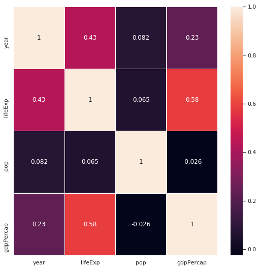

```python
import matplotlib.pyplot as plt
import seaborn as sns
sns.set()

# Draw a heatmap with the numeric values in each cell
f, ax = plt.subplots(figsize=(9, 9))
sns.heatmap(gapminder.corr(), annot=True, annot_kws={'fontsize': 12}, linewidths=.1, ax=ax)
```

##### 2.3.4.20 資料排序 -- sort_values()

```python
gapminder.sort_values(axis=0, by='pop', ascending=False, na_position='first', inplace=True)
```

```python
display(gapminder.loc[:, ['country','year','pop']].tail(10))
```

|  | country | year | pop |
| --- | --- | --- | --- |
| 1302 | Sao Tome and Principe | 1982 | 98593 |
| 422 | Djibouti | 1962 | 89898 |
| 1301 | Sao Tome and Principe | 1977 | 86796 |
| 1300 | Sao Tome and Principe | 1972 | 76595 |
| 421 | Djibouti | 1957 | 71851 |
| 1299 | Sao Tome and Principe | 1967 | 70787 |
| 1298 | Sao Tome and Principe | 1962 | 65345 |
| 420 | Djibouti | 1952 | 63149 |
| 1297 | Sao Tome and Principe | 1957 | 61325 |
| 1296 | Sao Tome and Principe | 1952 | 60011 |

### 3. Matplotlib

**說明 :**

https://matplotlib.org/

#### 3.0 安裝套件

- Python 2+ : pip install matplotlib
- Python 3+ : pip3 install matplotlib

#### 3.1 引用套件

```python
import matplotlib
import matplotlib.pyplot as plt
```

#### 3.2 繪製圖

- 折線圖
- 長條圖
- 散佈圖
- 圓餅圖

##### 3.2.1 折線圖

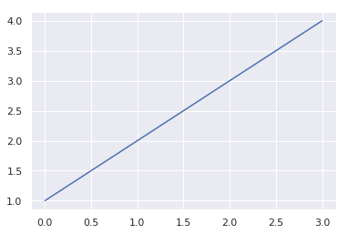

```python
import matplotlib.pyplot as plt
from matplotlib.font_manager import *
X = [1,2,3,4]
plt.plot(X)
plt.show()
```

[figure not shown]

```python
X = [1,2,3,4]
Y = [1,4,9,16]
plt.plot(X,Y)
plt.ylabel('頻率')
plt.xlabel('x label')
plt.title(u'中文')
plt.show()
```

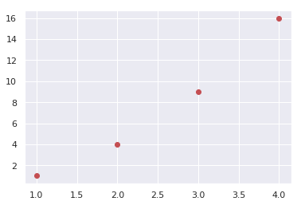

```python
plt.plot(X,Y,'ro')
```

##### 3.2.2 長條圖

```
<BarContainer object of 4 artists>
```

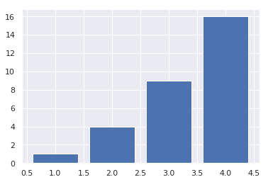

```python
import matplotlib.pyplot as plt
from matplotlib.font_manager import *
X = [1,2,3,4]
Y = [1,4,9,16]
plt.bar(X,Y)
```

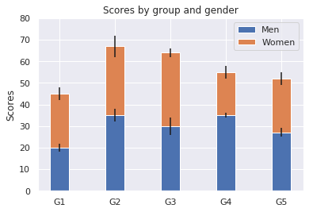

```python
import numpy as np
import matplotlib.pyplot as plt


N = 5
menMeans = (20, 35, 30, 35, 27)
womenMeans = (25, 32, 34, 20, 25)
menStd = (2, 3, 4, 1, 2)
womenStd = (3, 5, 2, 3, 3)
ind = np.arange(N)    # the x locations for the groups
width = 0.35       # the width of the bars: can also be len(x) sequence

p1 = plt.bar(ind, menMeans, width, yerr=menStd)
p2 = plt.bar(ind, womenMeans, width,
             bottom=menMeans, yerr=womenStd)

plt.ylabel('Scores')
plt.title('Scores by group and gender')
plt.xticks(ind, ('G1', 'G2', 'G3', 'G4', 'G5'))
plt.yticks(np.arange(0, 81, 10))
plt.legend((p1[0], p2[0]), ('Men', 'Women'))

plt.show()
```

##### 3.2.3 散佈圖

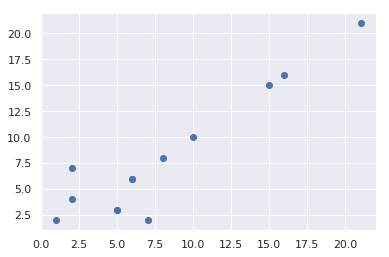

```python
import matplotlib.pyplot as plt
from matplotlib.font_manager import *
X = [1,5,2,6,2,5,7,10,15,6,8,21,16]
Y = [2,3,4,6,7,3,2,10,15,6,8,21,16]
plt.scatter(X,Y)
```

##### 3.2.4 圓餅圖

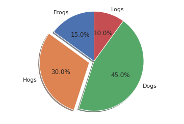

```python
import matplotlib.pyplot as plt

# Pie chart, where the slices will be ordered and plotted counter-clockwise:
labels = 'Frogs', 'Hogs', 'Dogs', 'Logs'
sizes = [15, 30, 45, 10]
explode = (0, 0.1, 0, 0)  # only "explode" the 2nd slice (i.e. 'Hogs')

fig1, ax1 = plt.subplots()
ax1.pie(sizes, explode=explode, labels=labels, autopct='%1.1f%%',
        shadow=True, startangle=90)
ax1.axis('equal')  # Equal aspect ratio ensures that pie is drawn as a circle.

plt.show()
```

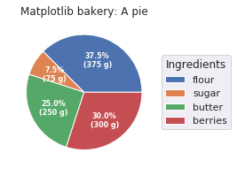

```python
import numpy as np
import matplotlib.pyplot as plt

fig, ax = plt.subplots(figsize=(10, 3), subplot_kw=dict(aspect="equal"))

recipe = ["375 g flour",
          "75 g sugar",
          "250 g butter",
          "300 g berries"]

data = [float(x.split()[0]) for x in recipe]
ingredients = [x.split()[-1] for x in recipe]


def func(pct, allvals):
    absolute = int(pct/100.*np.sum(allvals))
    return "{:.1f}%\n({:d} g)".format(pct, absolute)


wedges, texts, autotexts = ax.pie(data, autopct=lambda pct: func(pct, data),
                                  textprops=dict(color="w"))

ax.legend(wedges, ingredients,
          title="Ingredients",
          loc="center left",
          bbox_to_anchor=(1, 0, 0.5, 1))

plt.setp(autotexts, size=8, weight="bold")

ax.set_title("Matplotlib bakery: A pie")

plt.show()
```

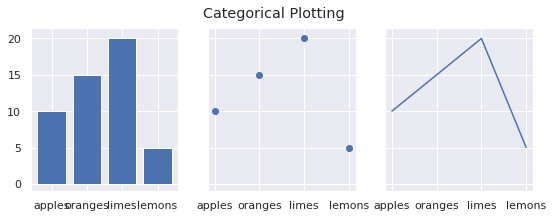

```python
import matplotlib.pyplot as plt

data = {'apples': 10, 'oranges': 15, 'lemons': 5, 'limes': 20}
names = list(data.keys())
values = list(data.values())

fig, axs = plt.subplots(1, 3, figsize=(9, 3), sharey=True)
axs[0].bar(names, values)
axs[1].scatter(names, values)
axs[2].plot(names, values)
fig.suptitle('Categorical Plotting')
```